# Salt Chemotaxis

Vivian Vy Le

2022-05-10

# Introduction

Guanylyl cyclases (*gcy*) are enzymes that can convert GTP to cGMP. These proteins are necessary for regulating the cGMP-gated cation channels. The regulation of cGMP-gated cation channels helps produce calcium currents, which helps nematodes chemotaxis and detect salt concentrations in the environment.

While all the information on chemosensation is in the *Caenorhabditis elegans*, there is an interest in studying salt chemosensation and the gcy gene family in host associated and parasitic nematodes. *Pristionochus pacifcius* is a non-parasitic nematode species that has a host assocation towards the Oriental beetle, and is attracted to a beetle sex pheromone.

It is unclear if the *gcy* genes in *P.pacificus* have similar gene functions in chemotaxis towards water soluble salts and are expressed in the amphid sensory neuron. With *P. pacificus*’ host association towards the Oriental beetle, it would be interesting to study if cGMP signaling contributes to the species’ host-seeking abilities.

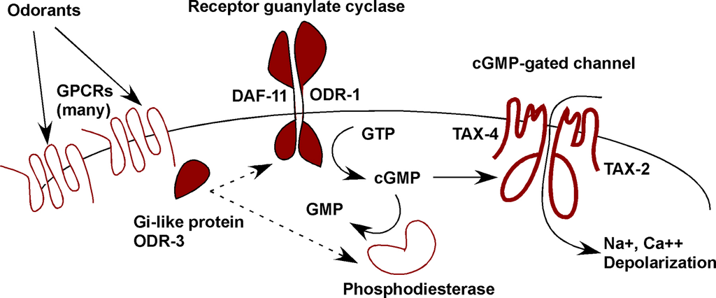

Source: Wormbook

## Load libraries

```r
library(tidyverse)
library(ggplot2)
library(here)
library(palettetown)
library(kableExtra)
```

### Load data

```r
salt <- read.csv(here("Data", "salt_CTX_data.csv"))
allgenes <- read.csv(here("Data", "salt_ctx_all_genes.csv"))
```

### View data

```r
glimpse(salt)
```

```
## Rows: 361
## Columns: 6
## $ ï..sample_id <int> 1, 2, 3, 4, 5, 6, 7, 8, 9, 10, 11, 12, 13, 14, 15, 16, 17~
## $ Strain       <chr> "wildtype (PS312)", "wildtype (PS312)", "wildtype (PS312)~
## $ Salt         <chr> "NH4Br", "NH4Br", "NH4Br", "NH4Br", "NH4Br", "NH4Br", "NH~
## $ A            <int> 11, 9, 42, 33, 13, 28, 25, 36, 44, 18, 61, 53, 31, 36, 42~
## $ C            <int> 0, 1, 7, 9, 0, 11, 10, 15, 13, 11, 33, 13, 16, 6, 19, 19,~
## $ Dispersed    <int> 32, 40, 107, 90, 95, 47, 61, 43, 55, 34, 23, 39, 38, 36, ~
```

```r
glimpse(allgenes)
```

```
## Rows: 1,026
## Columns: 6
## $ ï..sample_id <int> 1, 2, 3, 4, 5, 6, 7, 8, 9, 10, 11, 12, 13, 14, 15, 16, 17~
## $ Strain       <chr> "wildtype (PS312)", "wildtype (PS312)", "wildtype (PS312)~
## $ Salt         <chr> "NH4Br", "NH4Br", "NH4Br", "NH4Br", "NH4Br", "NH4Br", "NH~
## $ A            <int> 11, 9, 42, 33, 13, 28, 25, 36, 44, 18, 61, 53, 31, 36, 42~
## $ C            <int> 0, 1, 7, 9, 0, 11, 10, 15, 13, 11, 33, 13, 16, 6, 19, 19,~
## $ Dispersed    <int> 32, 40, 107, 90, 95, 47, 61, 43, 55, 34, 23, 39, 38, 36, ~
```

# Method

Chemosensation can be quantified by attraction and repulsion. To measure responses, we established a salt gradient on media.

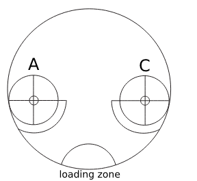

A represents attractant. Salts are considered attractants for the purpose of the experiment.

The list of salts used are the following:

- NH4Br
- NH4Cl
- NH4I
- LiCl
- NaCl
- NaAc

C represents the counter-attractant. We used water as the counter-attractant.

We wash and place the worms on the loading zone of the plate. Once the worms are placed onto the plate, the assay starts and the worms move for 3-5 hours before counting.

# Data analysis

The raw data consists of the number of worms in the attractant zone, the number of worms in the counter-attractant zone, and the number of worms dispersed from the loading zone. I calculated the chemotaxis index (CI) for the data set.

## *gcy-22* mutants

```r
salt_data <- salt %>%
  mutate(total = (A+C)) %>% #adding A and C for total worm participating in the assay
  mutate(CI = ((A-C)/(total))) %>% #calculating for the chemotaxis index with the worms participating in the assay
  mutate(participation = (total)/(total+Dispersed)) %>% #calculating for the fraction of worm participating from the population
  relocate("total", .before = "Dispersed") %>% #moved total column before dispersed
  mutate(Strain = factor(Strain,
                         levels = c("wildtype (PS312)", "gcy-22 (csu79)", "gcy-22 (csu80)"))) %>%
  mutate(Salt = factor(Salt,
                       levels = c("NH4Br", "NH4Cl", "NH4I", "LiCl", "NaCl", "NaAc")))

head(salt_data)
```

```
##   ï..sample_id           Strain  Salt  A  C total Dispersed        CI
## 1            1 wildtype (PS312) NH4Br 11  0    11        32 1.0000000
## 2            2 wildtype (PS312) NH4Br  9  1    10        40 0.8000000
## 3            3 wildtype (PS312) NH4Br 42  7    49       107 0.7142857
## 4            4 wildtype (PS312) NH4Br 33  9    42        90 0.5714286
## 5            5 wildtype (PS312) NH4Br 13  0    13        95 1.0000000
## 6            6 wildtype (PS312) NH4Br 28 11    39        47 0.4358974
##   participation
## 1     0.2558140
## 2     0.2000000
## 3     0.3141026
## 4     0.3181818
## 5     0.1203704
## 6     0.4534884
```

```r
gcy_data <- salt_data %>%
  select(Strain, Salt, CI) %>%
  group_by(Strain, Salt) %>%
  summarise(average = mean(CI, na.rm = TRUE), #calculating for average
            st_dev = sd(CI, na.rm = TRUE)) #calculating for standard deviation

gcy_table <- gcy_data %>%
  kbl() %>%
  kable_minimal() %>%
  kable_styling(full_width = FALSE)
gcy_table
```

| Strain | Salt | average | st_dev |
| --- | --- | --- | --- |
| wildtype (PS312) | NH4Br | 0.4723000 | 0.2801852 |
| wildtype (PS312) | NH4Cl | 0.3890365 | 0.2180472 |
| wildtype (PS312) | NH4I | 0.3209303 | 0.3367712 |
| wildtype (PS312) | LiCl | -0.0253479 | 0.2555786 |
| wildtype (PS312) | NaCl | 0.2568020 | 0.2616433 |
| wildtype (PS312) | NaAc | -0.8320220 | 0.1231720 |
| gcy-22 (csu79) | NH4Br | 0.8125558 | 0.1455565 |
| gcy-22 (csu79) | NH4Cl | 0.7449950 | 0.2613051 |
| gcy-22 (csu79) | NH4I | 0.8081437 | 0.1750308 |
| gcy-22 (csu79) | LiCl | 0.3711763 | 0.4323227 |
| gcy-22 (csu79) | NaCl | 0.5927835 | 0.3031273 |
| gcy-22 (csu79) | NaAc | -0.9636184 | 0.0760647 |
| gcy-22 (csu80) | NH4Br | 0.4582081 | 0.3494161 |
| gcy-22 (csu80) | NH4Cl | 0.4931531 | 0.1420100 |
| gcy-22 (csu80) | NH4I | 0.5775305 | 0.2225312 |
| gcy-22 (csu80) | LiCl | 0.4514149 | 0.2910491 |
| gcy-22 (csu80) | NaCl | 0.4614708 | 0.1327068 |
| gcy-22 (csu80) | NaAc | -0.8290242 | 0.1552247 |

### Plot for *gcy-22* mutants

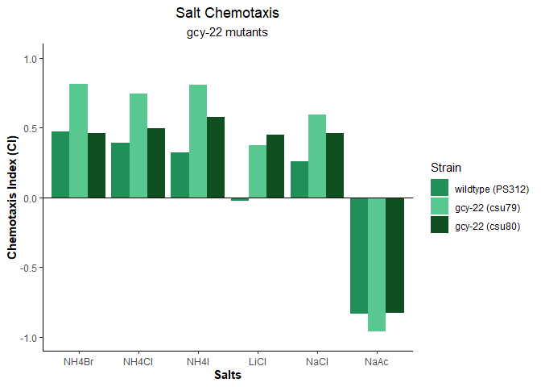

```r
plotbase <- function (data, x, y){
  ggplot(data = data, aes(x = Salt, y = average, fill = Strain)) + #creating a plot function for the data
    geom_col(position = "dodge") + #grouping the bars
    geom_hline(yintercept = 0) +
    ylim(-1,1) + #setting y axis limits for graph
    labs(title = "Salt Chemotaxis", #title of the plots stay the same
         x = "Salts", #x- and y-axis are the same
         y = "Chemotaxis Index (CI)") +
    theme(plot.title = element_text(hjust = 0.5),
          plot.subtitle = element_text(hjust = 0.5),
          axis.title = element_text(face = "bold"),
          panel.background = element_rect(fill = "white"),
          axis.line = element_line())
}
plotbase(gcy_data, x, y) +
  scale_fill_manual(values = pokepal(3)) +
  labs(subtitle = "gcy-22 mutants") #subtitle indicates which strains are on the plot
```

## Other genes involved in chemosensation

We also looked at salt responses for other genes involved in chemosensation: *daf-11*, *che-1*, and *tax-2*.

*daf-11* is another guanylyl cyclase.

*che-1* is a transcription factor necessary for the expression of a sensory amphid neuron, where most guanylyl cyclase proteins are expressed in *C. elegans*.

*tax-2* is a cGMP-gated channel at the end of the chemosensation pathway.

```r
allgenes_data <- allgenes %>%
  mutate(total = (A+C)) %>% #adding for total worms pariticpating in the assay
  mutate(CI = (A-C)/(total)) %>% #calculating for CI values
  mutate(participation = (total)/(total+Dispersed)) %>%
  relocate("total", .before = "Dispersed") %>%
  mutate(Salt = factor(Salt,
                       levels = c("NH4Br", "NH4Cl", "NH4I", "LiCl", "NaCl", "NaAc"))) %>%
  mutate(Strain = factor(Strain,
                         levels = c("wildtype (PS312)", "gcy-22 (csu79)", "gcy-22 (csu80)",
                                    "che-1 (ot5012)", "che-1 (ot5013)", "daf-11 (mok83)",
                                    "daf-11 (mok84)", "tax-2 (mok59)")))

head(allgenes_data)
```

```
##   ï..sample_id           Strain  Salt  A  C total Dispersed        CI
## 1            1 wildtype (PS312) NH4Br 11  0    11        32 1.0000000
## 2            2 wildtype (PS312) NH4Br  9  1    10        40 0.8000000
## 3            3 wildtype (PS312) NH4Br 42  7    49       107 0.7142857
## 4            4 wildtype (PS312) NH4Br 33  9    42        90 0.5714286
## 5            5 wildtype (PS312) NH4Br 13  0    13        95 1.0000000
## 6            6 wildtype (PS312) NH4Br 28 11    39        47 0.4358974
##   participation
## 1     0.2558140
## 2     0.2000000
## 3     0.3141026
## 4     0.3181818
## 5     0.1203704
## 6     0.4534884
```

```r
genes_ctx <- allgenes_data %>%
  group_by(Strain, Salt) %>%
  summarise(average = mean(CI, na.rm = TRUE), #calculating for averages
            st_dev = sd(CI, na.rm = TRUE)) #calculating for standard deviation


genes_table <- genes_ctx %>%
  kbl() %>%
  kable_minimal() %>%
  kable_styling(full_width = FALSE)
genes_table
```

| Strain | Salt | average | st_dev |
| --- | --- | --- | --- |
| wildtype (PS312) | NH4Br | 0.4674645 | 0.2582618 |
| wildtype (PS312) | NH4Cl | 0.4236726 | 0.2131185 |
| wildtype (PS312) | NH4I | 0.4892727 | 0.2643314 |
| wildtype (PS312) | LiCl | 0.3230904 | 0.3141646 |
| wildtype (PS312) | NaCl | 0.2517513 | 0.2743993 |
| wildtype (PS312) | NaAc | -0.8138807 | 0.1606556 |
| gcy-22 (csu79) | NH4Br | 0.8125558 | 0.1455565 |
| gcy-22 (csu79) | NH4Cl | 0.7449950 | 0.2613051 |
| gcy-22 (csu79) | NH4I | 0.8081437 | 0.1750308 |
| gcy-22 (csu79) | LiCl | 0.3711763 | 0.4323227 |
| gcy-22 (csu79) | NaCl | 0.5927835 | 0.3031273 |
| gcy-22 (csu79) | NaAc | -0.9636184 | 0.0760647 |
| gcy-22 (csu80) | NH4Br | 0.4582081 | 0.3494161 |
| gcy-22 (csu80) | NH4Cl | 0.4931531 | 0.1420100 |
| gcy-22 (csu80) | NH4I | 0.5775305 | 0.2225312 |
| gcy-22 (csu80) | LiCl | 0.4514149 | 0.2910491 |
| gcy-22 (csu80) | NaCl | 0.4614708 | 0.1327068 |
| gcy-22 (csu80) | NaAc | -0.8290242 | 0.1552247 |
| che-1 (ot5012) | NH4Br | 0.3234932 | 0.1986073 |
| che-1 (ot5012) | NH4Cl | 0.1433118 | 0.2543597 |
| che-1 (ot5012) | NH4I | 0.5629085 | 0.2368948 |
| che-1 (ot5012) | LiCl | 0.2546966 | 0.1912924 |
| che-1 (ot5012) | NaCl | 0.1879784 | 0.1952891 |
| che-1 (ot5012) | NaAc | -0.8792622 | 0.0785788 |
| che-1 (ot5013) | NH4Br | 0.4294805 | 0.2138974 |
| che-1 (ot5013) | NH4Cl | 0.1808612 | 0.2338635 |
| che-1 (ot5013) | NH4I | 0.4886201 | 0.1956031 |
| che-1 (ot5013) | LiCl | 0.2478281 | 0.1513705 |
| che-1 (ot5013) | NaCl | 0.0949458 | 0.2166925 |
| che-1 (ot5013) | NaAc | -0.8639877 | 0.0889645 |
| daf-11 (mok83) | NH4Br | 0.2601476 | 0.2769736 |
| daf-11 (mok83) | NH4Cl | 0.2611575 | 0.2518602 |
| daf-11 (mok83) | NH4I | 0.3714055 | 0.2492058 |
| daf-11 (mok83) | LiCl | -0.1125690 | 0.3849129 |
| daf-11 (mok83) | NaCl | 0.1259002 | 0.3724170 |
| daf-11 (mok83) | NaAc | 0.1164215 | 0.3566864 |
| daf-11 (mok84) | NH4Br | 0.2626926 | 0.1864208 |
| daf-11 (mok84) | NH4Cl | 0.3058530 | 0.2925601 |
| daf-11 (mok84) | NH4I | 0.4027702 | 0.2571719 |
| daf-11 (mok84) | LiCl | 0.0458998 | 0.3194682 |
| daf-11 (mok84) | NaCl | -0.0274176 | 0.3520775 |
| daf-11 (mok84) | NaAc | 0.0383275 | 0.2953435 |
| tax-2 (mok59) | NH4Br | 0.0483079 | 0.1702545 |
| tax-2 (mok59) | NH4Cl | -0.0090738 | 0.2497797 |
| tax-2 (mok59) | NH4I | 0.0481744 | 0.2252583 |
| tax-2 (mok59) | LiCl | -0.0297301 | 0.3270461 |
| tax-2 (mok59) | NaCl | 0.1009263 | 0.1600127 |
| tax-2 (mok59) | NaAc | 0.0991827 | 0.2454769 |

### Separating by gene and strains

```r
daf<-genes_ctx %>% #separating for daf-11
  filter(Strain == "wildtype (PS312)" | Strain == "daf-11 (mok83)" | Strain == "daf-11 (mok84)")
glimpse(daf)
```

```
## Rows: 18
## Columns: 4
## Groups: Strain [3]
## $ Strain  <fct> wildtype (PS312), wildtype (PS312), wildtype (PS312), wildtype~
## $ Salt    <fct> NH4Br, NH4Cl, NH4I, LiCl, NaCl, NaAc, NH4Br, NH4Cl, NH4I, LiCl~
## $ average <dbl> 0.46746447, 0.42367265, 0.48927265, 0.32309039, 0.25175131, -0~
## $ st_dev  <dbl> 0.2582618, 0.2131185, 0.2643314, 0.3141646, 0.2743993, 0.16065~
```

```r
che1 <-genes_ctx %>% #separting for che-1
  filter(Strain == "wildtype (PS312)" | Strain == "che-1 (ot5012)" | Strain == "che-1 (ot5013)")
glimpse(che1)
```

```
## Rows: 18
## Columns: 4
## Groups: Strain [3]
## $ Strain  <fct> wildtype (PS312), wildtype (PS312), wildtype (PS312), wildtype~
## $ Salt    <fct> NH4Br, NH4Cl, NH4I, LiCl, NaCl, NaAc, NH4Br, NH4Cl, NH4I, LiCl~
## $ average <dbl> 0.46746447, 0.42367265, 0.48927265, 0.32309039, 0.25175131, -0~
## $ st_dev  <dbl> 0.25826178, 0.21311852, 0.26433135, 0.31416459, 0.27439927, 0.~
```

```r
tax <-genes_ctx %>% #separating for tax-2
   filter(Strain == "wildtype (PS312)" | Strain == "tax-2 (mok59)")
glimpse(tax)
```

```
## Rows: 12
## Columns: 4
## Groups: Strain [2]
## $ Strain  <fct> wildtype (PS312), wildtype (PS312), wildtype (PS312), wildtype~
## $ Salt    <fct> NH4Br, NH4Cl, NH4I, LiCl, NaCl, NaAc, NH4Br, NH4Cl, NH4I, LiCl~
## $ average <dbl> 0.467464474, 0.423672648, 0.489272654, 0.323090386, 0.25175131~
## $ st_dev  <dbl> 0.2582618, 0.2131185, 0.2643314, 0.3141646, 0.2743993, 0.16065~
```

### Plot for *daf-11*, *che-1*, and *tax-2*

By separating the data for each gene, this would show a better comparison between wildtype and mutant strains.

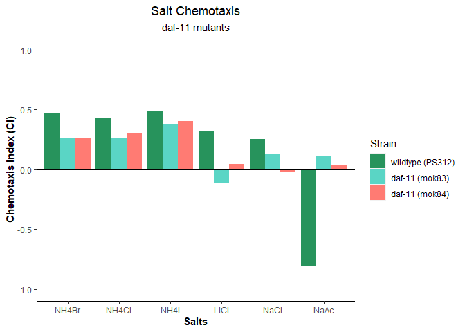

```r
daf_pal <- c("#27935C", "#5ad5c5", "#ff7b73")

plotbase(daf, x, y) +
  scale_fill_manual(values = daf_pal) +
  labs(subtitle = "daf-11 mutants")
```

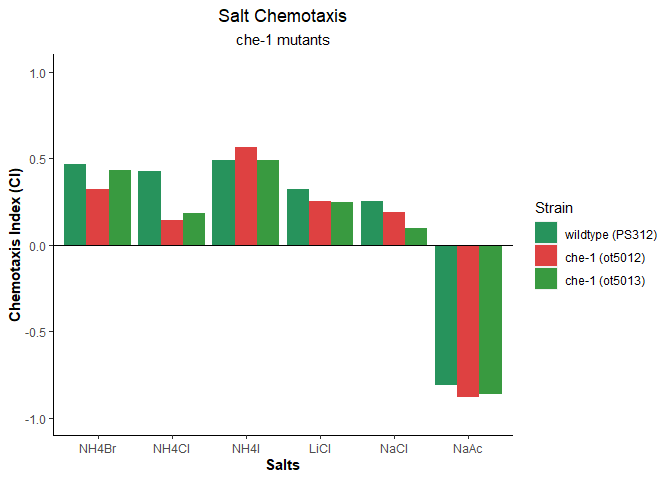

```r
che_pal <- c("#27935C", "#de4141", "#399A40") #creating a palette for che-1 plot

plotbase(che1, x, y) +
  scale_fill_manual(values = che_pal) +
  labs(subtitle = "che-1 mutants")
```

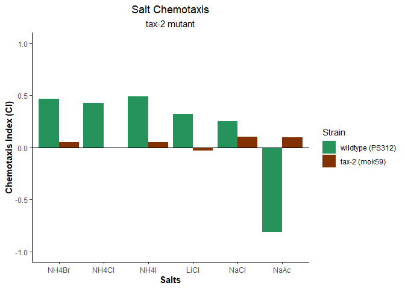

```r
tax_pal <- c("#27935C", "#833100") #creating a palette for tax-2 plot

plotbase(tax, x, y) +
  scale_fill_manual(values = tax_pal) +
  labs(subtitle = "tax-2 mutant")
```

### Plot for all mutants

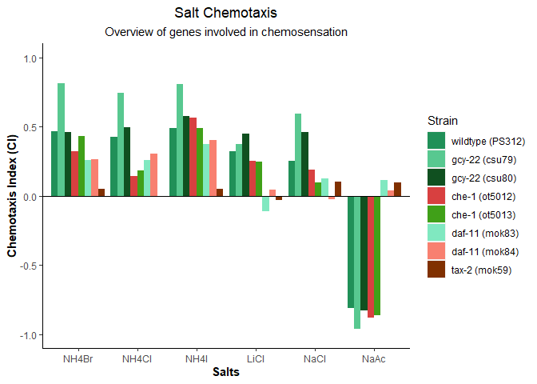

```r
plotbase(genes_ctx, x, y) +
  scale_fill_manual(values = pokepal(3)) +
  labs(subtitle = "Overview of genes involved in chemosensation")
```